```python
%load_ext rpy2.ipython
%R require(ggplot2)
%R require(reshape2)
None
```

```
The rpy2.ipython extension is already loaded. To reload it, use:
  %reload_ext rpy2.ipython
```

# [DBN](http://deeplearning.net/tutorial/DBN.html)

DBN은 training data의 'deep hierarchical representation'을 추출한다.

```python
! ls -l ./*py
```

```
-rw-rw-r-- 1 sungmk sungmk 17117  2월 18 14:33 ./DBN.py
-rw-rw-r-- 1 sungmk sungmk 17006  2월 17 17:58 ./logistic_sgd.py
-rw-rw-r-- 1 sungmk sungmk 14267  2월 17 17:58 ./mlp.py
-rw-rw-r-- 1 sungmk sungmk 10113  2월 17 17:58 ./rbm.py
-rw-rw-r-- 1 sungmk sungmk  5101  2월 17 17:59 ./utils.py
```

```python
! ls -al ../data/
```

```
합계 723696
drwxrwxr-x 2 sungmk sungmk     4096  2월 18 14:01 .
drwxrwxr-x 4 sungmk sungmk     4096  2월 18 14:00 ..
-rw-rw-r-- 1 sungmk sungmk 16168813  2월 17 14:42 mnist.pkl.gz
-rw-rw-r-- 1 sungmk sungmk 32351820  2월 17 14:42 mrna_20160125-200855_type1_00.pkl.gz
-rw-rw-r-- 1 sungmk sungmk 32096294  2월 17 14:42 mrna_20160125-200855_type1_01.pkl.gz
-rw-rw-r-- 1 sungmk sungmk 32032107  2월 17 14:42 mrna_20160125-200855_type1_02.pkl.gz
-rw-rw-r-- 1 sungmk sungmk 32024240  2월 17 14:42 mrna_20160125-200855_type1_03.pkl.gz
-rw-rw-r-- 1 sungmk sungmk 31956428  2월 17 14:42 mrna_20160125-200855_type1_04.pkl.gz
-rw-rw-r-- 1 sungmk sungmk 32039357  2월 17 14:42 mrna_20160125-200855_type1_05.pkl.gz
-rw-rw-r-- 1 sungmk sungmk 32070663  2월 17 14:42 mrna_20160125-200855_type1_06.pkl.gz
-rw-rw-r-- 1 sungmk sungmk 32204918  2월 17 14:43 mrna_20160125-200855_type1_07.pkl.gz
-rw-rw-r-- 1 sungmk sungmk 32198752  2월 17 14:43 mrna_20160125-200855_type1_08.pkl.gz
-rw-rw-r-- 1 sungmk sungmk 32179649  2월 17 14:43 mrna_20160125-200855_type1_09.pkl.gz
-rw-rw-r-- 1 sungmk sungmk 32127906  2월 17 14:43 mrna_20160125-200855_type1_10.pkl.gz
-rw-rw-r-- 1 sungmk sungmk 32073768  2월 17 14:43 mrna_20160125-200855_type1_11.pkl.gz
-rw-rw-r-- 1 sungmk sungmk 31934600  2월 17 14:43 mrna_20160125-200855_type1_12.pkl.gz
-rw-rw-r-- 1 sungmk sungmk 32026200  2월 17 14:43 mrna_20160125-200855_type1_13.pkl.gz
-rw-rw-r-- 1 sungmk sungmk 32055890  2월 17 14:43 mrna_20160125-200855_type1_14.pkl.gz
-rw-rw-r-- 1 sungmk sungmk 28513728  2월 17 14:43 mrna_20160125-200855_type1_15.pkl.gz
-rw-rw-r-- 1 sungmk sungmk 31922694  2월 17 14:43 mrna_20160125-200855_type2_00.pkl.gz
-rw-rw-r-- 1 sungmk sungmk 32040832  2월 17 14:43 mrna_20160125-200855_type2_01.pkl.gz
-rw-rw-r-- 1 sungmk sungmk 32037288  2월 17 14:43 mrna_20160125-200855_type2_02.pkl.gz
-rw-rw-r-- 1 sungmk sungmk 11443611  2월 17 14:43 mrna_20160125-200855_type2_03.pkl.gz
-rw-rw-r-- 1 sungmk sungmk 32089986  2월 17 14:43 mrna_20160125-200855_type3_00.pkl.gz
-rw-rw-r-- 1 sungmk sungmk 31963722  2월 17 14:43 mrna_20160125-200855_type3_01.pkl.gz
-rw-rw-r-- 1 sungmk sungmk 32017167  2월 17 14:43 mrna_20160125-200855_type3_02.pkl.gz
-rw-rw-r-- 1 sungmk sungmk 11435459  2월 17 14:43 mrna_20160125-200855_type3_03.pkl.gz
```

```python
import os
import sys
import timeit  # start time, end time ..

import numpy

import theano
import theano.tensor as T
from theano.sandbox.rng_mrg import MRG_RandomStreams   # random number

from logistic_sgd import LogisticRegression, load_data # logistic
from mlp import HiddenLayer
from rbm import RBM

import cPickle, gzip
```

Input data 살펴보기

```python
with gzip.open('../data/mrna_20160125-200855_type1_00.pkl.gz', 'rb') as f:
    dataX, dataY = cPickle.load(f)
%R -i dataX
%R -i dataY
```

```
[1]   500 20502
```

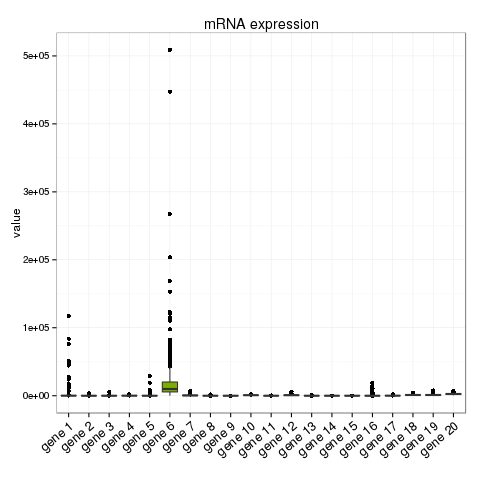

```python
%%R
p1 = function(mat){
    df = melt(mat)
    df = transform(df, Var2=factor(Var2, levels=as.character(Var2)))

        p = ggplot(df, aes(x=Var2, y=value, fill=Var2))+
        geom_boxplot()+
        ggtitle('mRNA expression') +xlab('')+theme_bw()+
        theme(axis.text.x=element_text(angle=40, hjust=1, size=13), legend.position='none')
    show(p)
    }

print (dim(dataX))
mat = dataX[,1:20]
colnames(mat) = paste('gene',1:20)
p1(mat)
```

## Normalization

- 대부분 activation function의 경우 그림과 같이 output signal에 미치는 input값의 범위가 매우 좁다
  - input 값의 범위가 아무리 커도 output 값은 0과 1사이로 압축됨.
  - 이러한 이유로, sigmoid와 같은 activation function을 squashing function이라고도 함

[figure not shown]

- 이러한 squashing problem에 대한 해답은 모든 input 을 0근처 매우 작은 범위로 만드는 것.
  - 보통 표준정규화 방법을 많이 쓰지만 input이 정규분포를 따르지 않는 경우 아래와 같이 0과 1사이 값으로 변형하는 것이 적합할 수 있음.

[figure not shown]

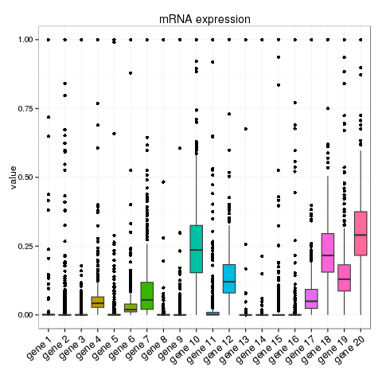

```python
%%R

norm_mat = apply(mat, 2, function(x) ( x-min(x))/(max(x)-min(x))  )
p1(norm_mat)
```

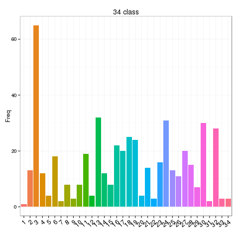

```python
%%R
df= data.frame(table( dataY ))

ggplot(df, aes(x=dataY, y=Freq, fill=dataY)) +
geom_bar(stat='identity') +
ggtitle('34 class') + xlab('')+theme_bw()+
theme(axis.text.x=element_text(angle=40, hjust=1, size=13), legend.position='none')
```

LoadData()

```python
import cPickle, gzip
import numpy
import theano
import theano.tensor as T
import glob

def LoadData():
    def Normalize(dataX):
        out = []
        for idx, x in enumerate(zip(* dataX)):
            if (idx+1) % 5000 == 0:
                print '%d features were normalized ..' %(idx+1)
            if d_max[idx] - d_min[idx] == 0:
                tmp = [(x - d_min[idx])]
            else:
                tmp = [(x - d_min[idx])/(d_max[idx]-d_min[idx])]
            out += tmp
        return theano.shared( numpy.asarray( zip(* out) , dtype=theano.config.floatX) , borrow=True)
    def MergeData(lst):
        for idx, FILE in enumerate( sorted( lst)) :
            print 'read %s ..' %(FILE)
            with gzip.open(FILE,'rb') as f:
                d = cPickle.load(f)
                if idx == 0:
                    dataX = d[0]
                    dataY = d[1]
                else:
                    dataX = numpy.concatenate( ( dataX, d[0] ) )
                    dataY = numpy.append( dataY, d[1])
                for idx, x in enumerate(zip(* d[0])):
                    d_min[idx]= numpy.min( (numpy.min(x), d_min.get(idx, numpy.inf)))
                    d_max[idx]= numpy.max( (numpy.max(x), d_max.get(idx, 0  )))
        shared_y = theano.shared( numpy.asarray(dataY-1, dtype=theano.config.floatX), borrow=True)
        return dataX, T.cast(shared_y, 'int32')

    d_min = dict()
    d_max = dict()
    train_x, train_y = MergeData( glob.glob("../data/*type1_00.pkl.gz") )
    valid_x, valid_y = MergeData( glob.glob("../data/*type2_00.pkl.gz") )
    test_x,  test_y  = MergeData( glob.glob("../data/*type3_00.pkl.gz") )

    print 'train set normalization ..'
    shared_train_x = Normalize(train_x)
    print 'valid set normalization ..'
    shared_valid_x = Normalize(valid_x)
    print 'test set normalization ..'
    shared_test_x  = Normalize(test_x)
    return [(shared_train_x, train_y), (shared_valid_x, valid_y), (shared_test_x, test_y)]
```

```python
datasets = LoadData()
```

```
read ../data/mrna_20160125-200855_type1_00.pkl.gz ..
read ../data/mrna_20160125-200855_type2_00.pkl.gz ..
read ../data/mrna_20160125-200855_type3_00.pkl.gz ..
train set normalization ..
5000 features were normalized ..
10000 features were normalized ..
15000 features were normalized ..
20000 features were normalized ..
valid set normalization ..
5000 features were normalized ..
10000 features were normalized ..
15000 features were normalized ..
20000 features were normalized ..
test set normalization ..
5000 features were normalized ..
10000 features were normalized ..
15000 features were normalized ..
20000 features were normalized ..
```

```python
train_x , train_y = datasets[0]

dataX = train_x.get_value()
f= theano.function([], train_y)
dataY = f()

%R -i dataX
%R -i dataY
```

```
[1]   500 20502
```

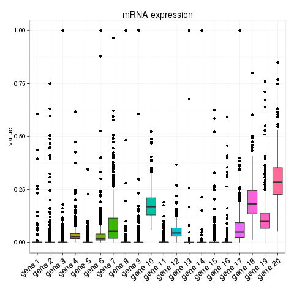

```python
%%R
print (dim(dataX))
mat = dataX[,1:20]
colnames(mat) = paste('gene',1:20)

p1(mat)
```

- class DBN() 구조
  - layers
    - rbm layers
    - mlp layer (sigmoid layers)
    - logistic layer
  - params = [W b W b]
    - sigmoid_layer.W
    - sigmoid_layer.b
    - logLayer.W
    - logLayer.b

```python
class DBN(object):
    def __init__(self, numpy_rng, theano_rng, n_ins, hidden_layers_sizes, n_outs):

        self.sigmoid_layers = []
        self.rbm_layers = []
        self.params = []
        self.n_layers = len(hidden_layers_sizes)

        assert self.n_layers > 0

        if not theano_rng:
            theano_rng = MRG_RandomStreams(numpy_rng.randint(2 ** 30))

        self.x = T.matrix('x')
        self.y = T.ivector('y')

        for i in xrange(self.n_layers):
            if i == 0:
                input_size = n_ins
            else:
                input_size = hidden_layers_sizes[i - 1]
            if i == 0:
                layer_input = self.x
            else:
                layer_input = self.sigmoid_layers[-1].output

            sigmoid_layer = HiddenLayer(rng=numpy_rng,
                                        input=layer_input,
                                        n_in=input_size,
                                        n_out=hidden_layers_sizes[i],
                                        activation=T.nnet.sigmoid)

            self.sigmoid_layers.append(sigmoid_layer)
            self.params.extend(sigmoid_layer.params)

            rbm_layer = RBM(numpy_rng=numpy_rng,
                            theano_rng=theano_rng,
                            input=layer_input,
                            n_visible=input_size,
                            n_hidden=hidden_layers_sizes[i],
                            W=sigmoid_layer.W,
                            hbias=sigmoid_layer.b)
            self.rbm_layers.append(rbm_layer)

        self.logLayer = LogisticRegression(
            input=self.sigmoid_layers[-1].output,
            n_in=hidden_layers_sizes[-1],
            n_out=n_outs)

        self.params.extend(self.logLayer.params)
        self.finetune_cost = self.logLayer.negative_log_likelihood(self.y)
        self.errors = self.logLayer.errors(self.y)

    def pretraining_functions(self, train_set_x, batch_size, k):
        index  = T.lscalar('index')
        learning_rate = T.scalar('lr')
        n_batches = train_set_x.get_value(borrow=True).shape[0] / batch_size

        batch_begin = index * batch_size
        batch_end = batch_begin + batch_size

        pretrain_fns = []
        for rbm in self.rbm_layers:
            cost, updates = rbm.get_cost_updates(learning_rate, persistent=None, k=k)
            fn = theano.function(
                inputs=[index, theano.Param(learning_rate, default=0.1)],
                outputs=cost,
                updates=updates,
                givens={
                    self.x: train_set_x[batch_begin:batch_end]
                }
            )
            pretrain_fns.append(fn)
        return pretrain_fns

    def build_finetune_functions(self, datasets, batch_size, learning_rate):
        (train_set_x, train_set_y) = datasets[0]
        (valid_set_x, valid_set_y) = datasets[1]
        (test_set_x, test_set_y)   = datasets[2]

        n_valid_batches = valid_set_x.get_value(borrow=True).shape[0]
        n_valid_batches /= batch_size
        n_test_batches = test_set_x.get_value(borrow=True).shape[0]
        n_test_batches /= batch_size

        index = T.lscalar('index')
        gparams = T.grad(self.finetune_cost, self.params)

        updates = []
        for param, gparam in zip(self.params, gparams):
            updates.append((param, param - gparam * learning_rate))

        train_fn = theano.function(
            inputs=[index],
            outputs=self.finetune_cost,
            updates=updates,
            givens={
                self.x: train_set_x[
                    index * batch_size: (index + 1) * batch_size
                ],
                self.y: train_set_y[
                    index * batch_size: (index + 1) * batch_size
                ]
            }
        )

        test_score_i = theano.function(
            [index],
            self.errors,
            givens={
                self.x: test_set_x[
                    index * batch_size: (index + 1) * batch_size
                ],
                self.y: test_set_y[
                    index * batch_size: (index + 1) * batch_size
                ]
            }
        )

        valid_score_i = theano.function(
            [index],
            self.errors,
            givens={
                self.x: valid_set_x[
                    index * batch_size: (index + 1) * batch_size
                ],
                self.y: valid_set_y[
                    index * batch_size: (index + 1) * batch_size
                ]
            }
        )
        def valid_score():
            return [valid_score_i(i) for i in xrange(n_valid_batches)]
        def test_score():
            return [test_score_i(i)  for i in xrange(n_test_batches)]


        return train_fn, valid_score, test_score
```

> python DBN.py

if __name__ == '__main__': test_DBN()

test_DBN()

```python
def test_DBN(finetune_lr=0.1, pretraining_epochs=100,
             pretrain_lr=0.01, k=1, training_epochs=100000,
             dataset=None, batch_size=20):

#    datasets = load_data(dataset)
    datasets = LoadData()

    train_set_x, train_set_y = datasets[0]
    valid_set_x, valid_set_y = datasets[1]
    test_set_x, test_set_y = datasets[2]
    n_train_batches = train_set_x.get_value(borrow=True).shape[0] / batch_size

    numpy_rng = numpy.random.RandomState(123)

    #########################
    #  Network construction #
    #########################
    dbn = DBN(numpy_rng=numpy_rng, theano_rng=None, n_ins=20502,
              hidden_layers_sizes=[1000],n_outs=34)

    #########################
    # PRETRAINING THE MODEL #
    #########################
    print '... getting the pretraining functions'
    pretraining_fns = dbn.pretraining_functions(train_set_x=train_set_x,
                                                batch_size=batch_size,
                                                k=k)

    print '... pre-training the model'
    start_time = timeit.default_timer()
    for i in xrange(dbn.n_layers):
        for epoch in xrange(pretraining_epochs):
            c = []
            for batch_index in xrange(n_train_batches):
                c.append(pretraining_fns[i](index=batch_index,
                                            lr=pretrain_lr))
            print 'Pre-training layer %i, epoch %d, cost ' % (i, epoch),
            print numpy.mean(c)

    end_time = timeit.default_timer()
    print >> sys.stderr, ('The pretraining code for file '+
                          ' ran for %.2fm' % ((end_time - start_time) / 60.))
    ########################
    # FINETUNING THE MODEL #
    ########################

    print '... getting the finetuning functions'
    train_fn, validate_model, test_model = dbn.build_finetune_functions(
        datasets=datasets,
        batch_size=batch_size,
        learning_rate=finetune_lr
    )

    print '... finetuning the model'
    patience = 4 * n_train_batches
    patience_increase = 2.
    improvement_threshold = 0.995
    validation_frequency = min(n_train_batches, patience / 2)

    best_validation_loss = numpy.inf
    test_score = 0.
    start_time = timeit.default_timer()

    done_looping = False
    epoch = 0

    while (epoch < training_epochs) and (not done_looping):
        epoch = epoch + 1
        for minibatch_index in xrange(n_train_batches):

            minibatch_avg_cost = train_fn(minibatch_index)
            iter = (epoch - 1) * n_train_batches + minibatch_index

            if (iter + 1) % validation_frequency == 0:

                validation_losses = validate_model()
                this_validation_loss = numpy.mean(validation_losses)
                print(
                    'epoch %i, minibatch %i/%i, validation error %f %%'
                    % (
                        epoch,
                        minibatch_index + 1,
                        n_train_batches,
                        this_validation_loss * 100.
                    )
                )

                if this_validation_loss < best_validation_loss:
                    if (
                        this_validation_loss < best_validation_loss *
                        improvement_threshold
                    ):
                        patience = max(patience, iter * patience_increase)

                    best_validation_loss = this_validation_loss
                    best_iter = iter

                    test_losses = test_model()
                    test_score = numpy.mean(test_losses)
                    print(('     epoch %i, minibatch %i/%i, test error of '
                           'best model %f %%') %
                          (epoch, minibatch_index + 1, n_train_batches,
                           test_score * 100.))

                    # save the best model
                    with gzip.open('best_dbn_model.pkl.gz', 'wb') as f:
                        cPickle.dump(dbn, f, protocol=cPickle.HIGHEST_PROTOCOL)

            if patience <= iter:
                done_looping = True
                break

    end_time = timeit.default_timer()
    print(
        (
            'Optimization complete with best validation score of %f %%, '
            'obtained at iteration %i, '
            'with test performance %f %%'
        ) % (best_validation_loss * 100., best_iter + 1, test_score * 100.)
    )
    print >> sys.stderr, ('The fine tuning code for file '+
                          ' ran for %.2fm' % ((end_time - start_time)
                                              / 60.))
```

```python
test_DBN()
```

```
read ../data/mrna_20160125-200855_type1_00.pkl.gz ..
read ../data/mrna_20160125-200855_type2_00.pkl.gz ..
read ../data/mrna_20160125-200855_type3_00.pkl.gz ..
train set normalization ..
5000 features were normalized ..
10000 features were normalized ..
15000 features were normalized ..
20000 features were normalized ..
valid set normalization ..
5000 features were normalized ..
10000 features were normalized ..
15000 features were normalized ..
20000 features were normalized ..
test set normalization ..
5000 features were normalized ..
10000 features were normalized ..
15000 features were normalized ..
20000 features were normalized ..
... getting the pretraining functions
... pre-training the model
Pre-training layer 0, epoch 0, cost  -12086.0654384
Pre-training layer 0, epoch 1, cost  -9030.44145931
Pre-training layer 0, epoch 2, cost  -8298.815724
Pre-training layer 0, epoch 3, cost  -7887.3046155
Pre-training layer 0, epoch 4, cost  -7487.95421336
Pre-training layer 0, epoch 5, cost  -7172.92133667
Pre-training layer 0, epoch 6, cost  -6873.82413471
Pre-training layer 0, epoch 7, cost  -6661.06461566
Pre-training layer 0, epoch 8, cost  -6471.35427713
Pre-training layer 0, epoch 9, cost  -6302.67852877
Pre-training layer 0, epoch 10, cost  -6152.94159413
Pre-training layer 0, epoch 11, cost  -6028.10208165
Pre-training layer 0, epoch 12, cost  -5912.29721168
Pre-training layer 0, epoch 13, cost  -5801.11093287
Pre-training layer 0, epoch 14, cost  -5705.5211822
Pre-training layer 0, epoch 15, cost  -5621.41115354
Pre-training layer 0, epoch 16, cost  -5544.2797966
Pre-training layer 0, epoch 17, cost  -5474.5343064
Pre-training layer 0, epoch 18, cost  -5412.46061153
Pre-training layer 0, epoch 19, cost  -5355.98418357
```

[output cut: 115 more lines]

```
epoch 18, minibatch 25/25, validation error 15.800000 %
epoch 19, minibatch 25/25, validation error 15.600000 %
epoch 20, minibatch 25/25, validation error 15.600000 %
epoch 21, minibatch 25/25, validation error 15.400000 %
epoch 22, minibatch 25/25, validation error 15.400000 %
epoch 23, minibatch 25/25, validation error 15.400000 %
epoch 24, minibatch 25/25, validation error 15.400000 %
epoch 25, minibatch 25/25, validation error 15.400000 %
epoch 26, minibatch 25/25, validation error 15.600000 %
epoch 27, minibatch 25/25, validation error 15.800000 %
epoch 28, minibatch 25/25, validation error 15.800000 %
epoch 29, minibatch 25/25, validation error 15.800000 %
epoch 30, minibatch 25/25, validation error 15.800000 %
epoch 31, minibatch 25/25, validation error 15.600000 %
Optimization complete with best validation score of 15.400000 %, obtained at iteration 400, with test performance 17.200000 %
```

```
The pretraining code for file  ran for 22.58m
The fine tuning code for file  ran for 6.35m
```

Result

... building the model ... getting the pretraining functions ... pre-training the model Pre-training layer 0, epoch 0, cost -6010.13 Pre-training layer 0, epoch 1, cost -4024.01 Pre-training layer 0, epoch 2, cost -3703.51 Pre-training layer 0, epoch 3, cost -3622.65 Pre-training layer 0, epoch 4, cost -3585.32 ... Pre-training layer 0, epoch 95, cost -3426.15 Pre-training layer 0, epoch 96, cost -3426.02 Pre-training layer 0, epoch 97, cost -3425.8 Pre-training layer 0, epoch 98, cost -3425.47 Pre-training layer 0, epoch 99, cost -3425.23 ... getting the finetuning functions ... finetuning the model epoch 1, minibatch 397/397, validation error 10.662651 % epoch 1, minibatch 397/397, test error of best model 11.144578 % epoch 2, minibatch 397/397, validation error 9.277108 % epoch 2, minibatch 397/397, test error of best model 9.638554 % epoch 3, minibatch 397/397, validation error 8.674699 % epoch 3, minibatch 397/397, test error of best model 8.915663 % epoch 4, minibatch 397/397, validation error 8.433735 % epoch 4, minibatch 397/397, test error of best model 8.192771 % epoch 5, minibatch 397/397, validation error 8.132530 % epoch 5, minibatch 397/397, test error of best model 8.012048 % ... epoch 442, minibatch 397/397, validation error 4.939759 % epoch 443, minibatch 397/397, validation error 4.939759 % epoch 444, minibatch 397/397, validation error 4.939759 % epoch 445, minibatch 397/397, validation error 4.939759 % epoch 446, minibatch 397/397, validation error 4.939759 % epoch 447, minibatch 397/397, validation error 4.939759 % Optimization complete with best validation score of 4.939759 %, obtained at iteration 88928, with test performance 6.265060 %The pretraining code for file DBN.py ran for 4.61m The fine tuning code for file DBN.py ran for 6.98m

최종 model 살펴보기

- (참고 MNIST data 결과)
  - 10개의 hidden node사용
    - train: {1: 5678, 2: 4968}
    - vald : {1: 1064, 2: 990}
    - test : {1: 1135, 2: 1032}

```python
w1, b1, w2, b2 = cPickle.load(gzip.open('mnist_1_2_dbn_param.pkl.gz','rb'))
W1, W2 = w1.T, w2.T
%R -i W1
%R -i b1
%R -i W2
%R -i b2
```

[figure not shown]

RBM의 구조

```
- EBMs with hidden units
- network without visible-visible and hidden-hidden connections
```

[figure not shown]

- 위 RBM network는 아래와 같은 Energy 값을 갖는다. $$ E(v, h) = - ( b_{i} v_{i} + c_{j}h_{j} + v_{i}W_{ij}h_{j} ) $$ $$ ( v, h \in { 0, 1 } )$$

<참고1> EBM에서 bias의 의미는? > 해당 node의 **preference**

```
- ex) If cj > 0,
        - hj 는 ON.
    - If cj < 0,
        - hj 는 OFF.
```

<참고2> EBM에서 weight의 의미는? > 연결된 두 node의 **연관성 (correlation)**

```
- ex) If Wij > 0,
        - vi, bj 는 둘 다 ON.
    - If Wij < 0,
        - vi, bj 둘 중에 하나는 OFF.
```

```python
%%R

plotw2 = function(W2, class, top='all') {
    top = ifelse(top =='all', ncol(W2), top)
    data.m = data.frame(variable=factor(1:ncol(W2), labels=1:ncol(W2)), value=W2[class,])
    data.m = transform(data.m, group = factor(ifelse(value> 0, 1, ifelse(value< 0,  -1,  0))))

    anno = paste('node number (with high weight) :',  which.max(data.m$value) )

        p=ggplot(data.m, aes(x=reorder(variable,-value), y=value, fill=group)) +
        geom_bar(stat='identity')+
        xlab('hidden nodes')+ylab('weights')+theme_bw()+
        scale_fill_manual(values=c('blue','red','black'))+
        theme(legend.position='none')+ggtitle(paste('class ',class,'\n',anno))+
        coord_cartesian(xlim=c(0,top))
    show(p)
    }
```

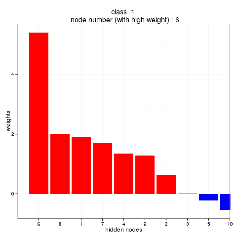

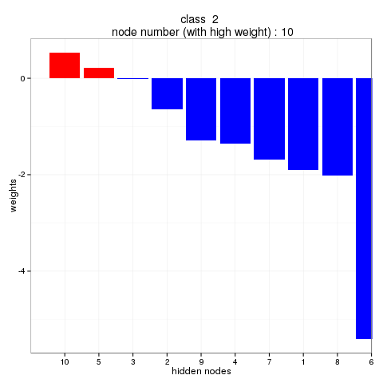

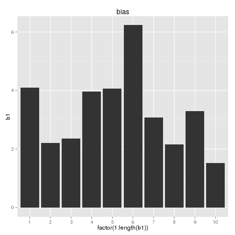

```python
%%R
plotw2(W2, class=1)
plotw2(W2, class=2)

ggplot(NULL, aes(x=factor(1:length(b1)),y=b1))+geom_bar(stat='identity')+ggtitle('bias')
```

```python
%%R

plotw1 = function(W1, hiddenNode, ncol=28){

    data.m = melt(matrix( W1[hiddenNode,], ncol=ncol, byrow=T))

        p = ggplot(data.m, aes(Var2, Var1)) +
        geom_raster(aes(fill = value))+theme_bw()+
        scale_fill_gradient2(low='blue', mid='white',high='red')+
        scale_y_reverse()+ggtitle(paste('hidden node',hiddenNode))
    show(p)
}
```

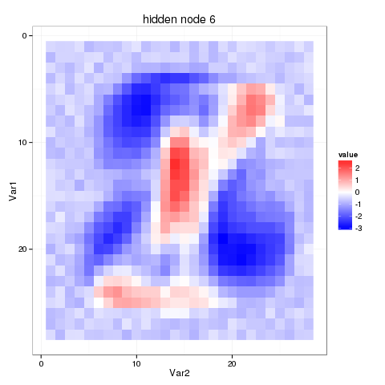

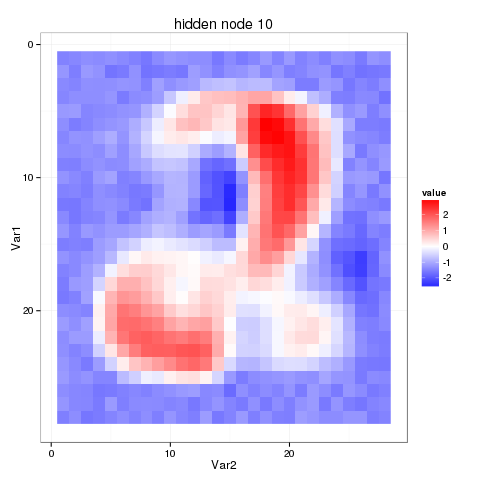

```python
%%R

plotw1(W1, hiddenNode=6)
plotw1(W1, hiddenNode=10)
```

```python
with gzip.open('best_dbn_model.pkl.cvt.gz','rb') as f:
    dbn = cPickle.load(f)
```

```python
dir(dbn)
```

```
['__class__',
 '__delattr__',
 '__dict__',
 '__doc__',
 '__format__',
 '__getattribute__',
 '__hash__',
 '__init__',
 '__module__',
 '__new__',
 '__reduce__',
 '__reduce_ex__',
 '__repr__',
 '__setattr__',
 '__sizeof__',
 '__str__',
 '__subclasshook__',
 '__weakref__',
 'build_finetune_functions',
 'errors',
 'finetune_cost',
 'logLayer',
 'n_layers',
 'params',
 'pretraining_functions',
 'rbm_layers',
 'sigmoid_layers',
 'x',
 'y']
```

```python
dbn.params
```

```
[W, b, W, b]
```

```python
W1 = dbn.params[0].get_value(borrow=True).T
b1 = dbn.params[1].get_value(borrow=True)
W2 = dbn.params[2].get_value(borrow=True).T
b2 = dbn.params[3].get_value(borrow=True)
%R -i W1
%R -i b1
%R -i W2
%R -i b2
```

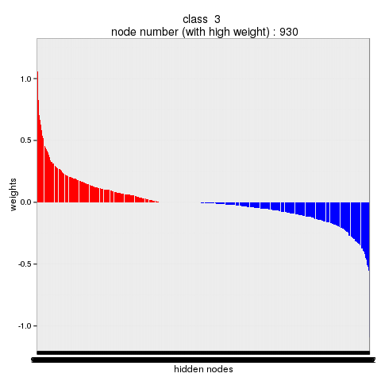

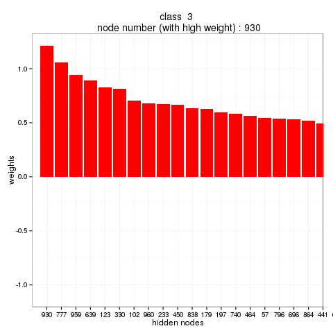

```python
%%R

dim(W2)
plotw2(W2, class=3)
plotw2(W2, class=3, top =20)
```

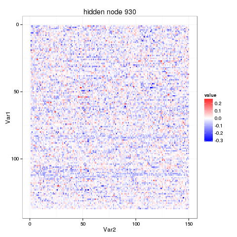

```python
%%R

plotw1(W1, hiddenNode=930, ncol=150 )
```

```python
%%R
plotw1_ver2  = function(W1, hiddenNode) {
    data.m = data.frame(variable=factor(1:ncol(W1)), labels=1:ncol(W1), value=W1[hiddenNode,])
    data.m = transform(data.m, group = factor(ifelse(value>  quantile(value, .999), 1, ifelse(value<  quantile(value, .001),  -1,  0))))

        p=ggplot(data.m, aes(x=variable, y=value, fill=group)) +
        geom_point(shape=21)+
        xlab('genes')+ylab('weights')+theme_bw()+ggtitle(paste('hidden node ',hiddenNode))+
        scale_fill_manual(values=c('blue','black','red'))+
        theme(legend.position='none',axis.ticks = element_blank(), axis.text.x=element_blank(), panel.grid=element_blank())
    show(p)
    }
```

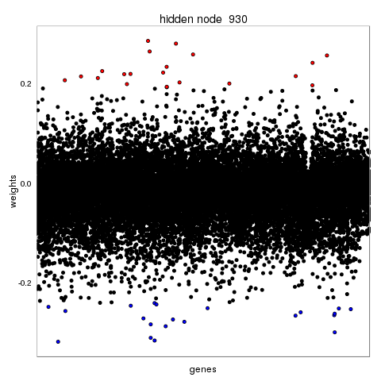

```python
%%R

plotw1_ver2(W1, hiddenNode=930)
```